# ChemTHEATRE スナメリデータ・クリーニングから作図まで

Akifumi Eguchi

2019/6/23

### ライブラリ読み込み

```r
library(tidyverse)
library(DT)
library(sessioninfo)
```

### データ読み込み

```r
#ChemTHEATREからダウンロードしてきたスナメリデータの読み込み
#読み込むファイルの名前はダウンロードしてきたものに合わせて適宜変更すること

chm.data <- read_tsv("measureddata_20190622140143.tsv") %>%
  select(-c("ProjectID", "ScientificName", "RegisterDate", "UpdateDate")) # sample.dataと重複する列の削除

sample.data <- read_tsv("samples_20190622140137.tsv")
```

今回はスナメリの測定データをダウンロードしたものを利用する。 `read_tsv()`関数を使ってデータを読み込む。 読み込んだデータの中からchm.data, sample.dataで重複する列は`select()`関数を使って先に落としておく。

### データ前処理

```r
#chm.dataとsample.dataをサンプルIDでマージ
merged.data <- chm.data %>% left_join(sample.data, by= "SampleID")
```

まず2つのデータを結合する。`chm.data`をベースに動かしていきたいので、`chm.data`に`left_join()`関数を使い、共通するサンプルIDをキーにして結合する。

```r
#不要な変数削除/ wet・fatの分割・totalのデータに絞り込むなど
marged.total.lipid <- merged.data %>%
                      filter(Unit == "ng/g lipid") %>% #脂肪重量データ抽出
                      filter(str_detect(ChemicalName, "Σ")) %>%  # sumではじまるものを抽出
                      filter(!ChemicalName %in% c("ΣOH-penta-PCB", "ΣOH-hexa-PCB", "ΣOH-hepta-PCB", "ΣOH-octa-PCB")) #個別要素の削除


marged.total.wet <- merged.data %>%
                    filter(Unit == "ng/g wet") %>%  #wet重量データ抽出
                    filter(str_detect(ChemicalName, "Σ")) %>%  # sumではじまるものを抽出
                    filter(!ChemicalName %in% c("ΣOH-penta-PCB", "ΣOH-hexa-PCB", "ΣOH-hepta-PCB", "ΣOH-octa-PCB")) #個別要素の削除

marged.total.wet$MeasuredValue[marged.total.wet$MeasuredValue < 0.05] <- 0.05 #log変換したいので0を埋めておく
```

続いてデータのクリーニングを行う。まず、化学物質の濃度の単位が格納されている`Unit`列を見てみると、ng/g lipid, ng/g wetの2つの濃度単位のデータがあることがわかる。異なる濃度単位のデータを比較するのはあまりイケていないので、`filter()`関数を使っていずれかの単位に絞り込み位をかけておく。これによりlipid, wetベースそれぞれのデータを作ることができる。  
続いて`ChemicalName`列に注目する。ここには様々な化学物質の個別異性体、各化学物質の名前が格納されており`MeasuredValue`列に格納されている濃度データと紐付いている。最初に図を作る段階では個別異性体のデータは細かすぎるので、合計値を表すΣを含む`ChemicalName`を`str_detect()`関数を使って抽出する。ただ、これをやると水酸化PCBの塩素数合計値も合わせて引っかかってしまうので、`ChemicalName`に塩素数合計値である“ΣOH-penta-PCB”, “ΣOH-hexa-PCB”, “ΣOH-hepta-PCB”, “ΣOH-octa-PCB”を含まないデータのみに絞り込む。  
これで大まかにデータは絞り込めたが、wet重量あたりの`MeasuredValue`列を確認してみると濃度0のデータが複数含まれていることがわかる。化学物質濃度は物によってかなり幅があるため、作図の際には対数表示で示すことが多い。しかし0は対数変換できないので、ひとまず最低濃度の半分程度である0.05の値を代入しておく。

```r
is_blank <- function(x) {is.na(x) | x == ""}

#すべてがNAの列を削除
unnecessary_col <- apply(marged.total.lipid, 2,
                         function(x){
                           all(is_blank(x))
                         })

marged.total.lipid <- marged.total.lipid[, !unnecessary_col]

unnecessary_col <- apply(marged.total.wet, 2,
                         function(x){
                           all(is_blank(x))
                         })

marged.total.wet <- marged.total.wet[, !unnecessary_col]
```

つづいてNAばかりの列を削除しておく。このコードは[Rで空行・空列を除去する方法](https://id.fnshr.info/2017/08/14/r-blank-row-col/)を参考にした。

### データの概観チェック

```r
datatable(marged.total.lipid,
    extensions = 'FixedColumns',
    options = list(
    dom = 't',
    scrollX = TRUE,
    scrollCollapse = TRUE)
  )
```

|  | MeasuredID | SampleID | ChemicalID | ChemicalName | ExperimentID | MeasuredValue | Unit | ProjectID | SampleType | TaxonomyID | UniqCodeType | UniqCode | SampleName | ScientificName | CommonName | CollectionYear | CollectionMonth | CollectionDay | CollectionRegion | CollectionCountry | CollectionArea | CollectionLatitudeFrom | CollectionLatitudeTo | CollectionLongitudeFrom | CollectionLongitudeTo | Sex | TissueOrgan | TissueLipid | Weight | … |
| --- | --- | --- | --- | --- | --- | --- | --- | --- | --- | --- | --- | --- | --- | --- | --- | --- | --- | --- | --- | --- | --- | --- | --- | --- | --- | --- | --- | --- | --- | --- |
| 1 | 24782 | SAA001903 | CH0000033 | ΣDDTs | EXA000001 | 68000 | ng/g lipid | PRA000030 | ST004 | 34892 | es-BANK | EW00736 | 9053 | Neophocaena phocaenoides | Finless Porpoise | 1990 |  |  | Asia | China | Dongshan | 23.65352778 | 23.71171389 | 117.2606639 | 117.2949778 | Male | Blubber | 87 | 27 | … |
| 2 | 24768 | SAA001903 | CH0000096 | ΣPCBs | EXA000001 | 5700 | ng/g lipid | PRA000030 | ST004 | 34892 | es-BANK | EW00736 | 9053 | Neophocaena phocaenoides | Finless Porpoise | 1990 |  |  | Asia | China | Dongshan | 23.65352778 | 23.71171389 | 117.2606639 | 117.2949778 | Male | Blubber | 87 | 27 | … |
| 3 | 24754 | SAA001903 | CH0000138 | ΣPBDEs | EXA000001 | 170 | ng/g lipid | PRA000030 | ST004 | 34892 | es-BANK | EW00736 | 9053 | Neophocaena phocaenoides | Finless Porpoise | 1990 |  |  | Asia | China | Dongshan | 23.65352778 | 23.71171389 | 117.2606639 | 117.2949778 | Male | Blubber | 87 | 27 | … |
| 4 | 24902 | SAA001903 | CH0000142 | ΣHBCDs | EXA000001 | 5.6 | ng/g lipid | PRA000030 | ST004 | 34892 | es-BANK | EW00736 | 9053 | Neophocaena phocaenoides | Finless Porpoise | 1990 |  |  | Asia | China | Dongshan | 23.65352778 | 23.71171389 | 117.2606639 | 117.2949778 | Male | Blubber | 87 | 27 | … |
| 5 | 24810 | SAA001903 | CH0000146 | ΣHCHs | EXA000001 | 1100 | ng/g lipid | PRA000030 | ST004 | 34892 | es-BANK | EW00736 | 9053 | Neophocaena phocaenoides | Finless Porpoise | 1990 |  |  | Asia | China | Dongshan | 23.65352778 | 23.71171389 | 117.2606639 | 117.2949778 | Male | Blubber | 87 | 27 | … |
| 6 | 24796 | SAA001903 | CH0000152 | ΣCHLs | EXA000001 | 770 | ng/g lipid | PRA000030 | ST004 | 34892 | es-BANK | EW00736 | 9053 | Neophocaena phocaenoides | Finless Porpoise | 1990 |  |  | Asia | China | Dongshan | 23.65352778 | 23.71171389 | 117.2606639 | 117.2949778 | Male | Blubber | 87 | 27 | … |
| 7 | 24783 | SAA001904 | CH0000033 | ΣDDTs | EXA000001 | 140000 | ng/g lipid | PRA000030 | ST004 | 34892 | es-BANK | EW00743 | 9063 | Neophocaena phocaenoides | Finless Porpoise | 1990 |  |  | Asia | China | Dongshan | 23.65352778 | 23.71171389 | 117.2606639 | 117.2949778 | Male | Blubber | 73 | 29 | … |
| 8 | 24769 | SAA001904 | CH0000096 | ΣPCBs | EXA000001 | 6500 | ng/g lipid | PRA000030 | ST004 | 34892 | es-BANK | EW00743 | 9063 | Neophocaena phocaenoides | Finless Porpoise | 1990 |  |  | Asia | China | Dongshan | 23.65352778 | 23.71171389 | 117.2606639 | 117.2949778 | Male | Blubber | 73 | 29 | … |
| 9 | 24755 | SAA001904 | CH0000138 | ΣPBDEs | EXA000001 | 120 | ng/g lipid | PRA000030 | ST004 | 34892 | es-BANK | EW00743 | 9063 | Neophocaena phocaenoides | Finless Porpoise | 1990 |  |  | Asia | China | Dongshan | 23.65352778 | 23.71171389 | 117.2606639 | 117.2949778 | Male | Blubber | 73 | 29 | … |
| 10 | 24903 | SAA001904 | CH0000142 | ΣHBCDs | EXA000001 | 37 | ng/g lipid | PRA000030 | ST004 | 34892 | es-BANK | EW00743 | 9063 | Neophocaena phocaenoides | Finless Porpoise | 1990 |  |  | Asia | China | Dongshan | 23.65352778 | 23.71171389 | 117.2606639 | 117.2949778 | Male | Blubber | 73 | 29 | … |

[output cut: 121 more lines]

```r
datatable(marged.total.wet,
    extensions = 'FixedColumns',
    options = list(
    dom = 't',
    scrollX = TRUE,
    scrollCollapse = TRUE)
  )
```

|  | MeasuredID | SampleID | ChemicalID | ChemicalName | ExperimentID | MeasuredValue | AlternativeData | Unit | ProjectID | SampleType | TaxonomyID | UniqCodeType | UniqCode | SampleName | ScientificName | CommonName | CollectionYear | CollectionMonth | CollectionDay | CollectionRegion | CollectionCountry | CollectionArea | CollectionLatitudeFrom | CollectionLatitudeTo | CollectionLongitudeFrom | CollectionLongitudeTo | Sex | TissueOrgan | Weight | … |
| --- | --- | --- | --- | --- | --- | --- | --- | --- | --- | --- | --- | --- | --- | --- | --- | --- | --- | --- | --- | --- | --- | --- | --- | --- | --- | --- | --- | --- | --- | --- |
| 1 | 83 | SAA000087 | CH0000157 | ΣBTs | EXA000001 | 434.9036 |  | ng/g wet | PRA000002 | ST004 | 34892 | es-BANK | EW00884 |  | Neophocaena phocaenoides | Finless porpoises | 1996 | 4 | 18 | Asia | Japan | Seto Inland Sea | 33.61055556 | 33.91 | 131.1952778 | 134.6513889 |  | Liver | 5.25 | … |
| 2 | 86 | SAA000087 | CH0000160 | ΣPTs | EXA000001 | 13.317 |  | ng/g wet | PRA000002 | ST004 | 34892 | es-BANK | EW00884 |  | Neophocaena phocaenoides | Finless porpoises | 1996 | 4 | 18 | Asia | Japan | Seto Inland Sea | 33.61055556 | 33.91 | 131.1952778 | 134.6513889 |  | Liver | 5.25 | … |
| 3 | 90 | SAA000087 | CH0000164 | Σoctyltins | EXA000001 | 1.5 |  | ng/g wet | PRA000002 | ST004 | 34892 | es-BANK | EW00884 |  | Neophocaena phocaenoides | Finless porpoises | 1996 | 4 | 18 | Asia | Japan | Seto Inland Sea | 33.61055556 | 33.91 | 131.1952778 | 134.6513889 |  | Liver | 5.25 | … |
| 4 | 94 | SAA000088 | CH0000157 | ΣBTs | EXA000001 | 188.4385 |  | ng/g wet | PRA000002 | ST004 | 34892 | es-BANK | EW00812 |  | Neophocaena phocaenoides | Finless porpoises | 1999 | 7 | 19 | Asia | Japan | Seto Inland Sea | 33.61055556 | 33.91 | 131.1952778 | 134.6513889 |  | Liver |  | … |
| 5 | 97 | SAA000088 | CH0000160 | ΣPTs | EXA000001 | 8.731 |  | ng/g wet | PRA000002 | ST004 | 34892 | es-BANK | EW00812 |  | Neophocaena phocaenoides | Finless porpoises | 1999 | 7 | 19 | Asia | Japan | Seto Inland Sea | 33.61055556 | 33.91 | 131.1952778 | 134.6513889 |  | Liver |  | … |
| 6 | 101 | SAA000088 | CH0000164 | Σoctyltins | EXA000001 | 0.05 | - | ng/g wet | PRA000002 | ST004 | 34892 | es-BANK | EW00812 |  | Neophocaena phocaenoides | Finless porpoises | 1999 | 7 | 19 | Asia | Japan | Seto Inland Sea | 33.61055556 | 33.91 | 131.1952778 | 134.6513889 |  | Liver |  | … |
| 7 | 105 | SAA000089 | CH0000157 | ΣBTs | EXA000001 | 227.7925 |  | ng/g wet | PRA000002 | ST004 | 34892 | es-BANK | EW00873 |  | Neophocaena phocaenoides | Finless porpoises | 1995 | 5 | 21 | Asia | Japan | Seto Inland Sea | 33.61055556 | 33.91 | 131.1952778 | 134.6513889 |  | Liver | 6.4 | … |
| 8 | 108 | SAA000089 | CH0000160 | ΣPTs | EXA000001 | 13.59 |  | ng/g wet | PRA000002 | ST004 | 34892 | es-BANK | EW00873 |  | Neophocaena phocaenoides | Finless porpoises | 1995 | 5 | 21 | Asia | Japan | Seto Inland Sea | 33.61055556 | 33.91 | 131.1952778 | 134.6513889 |  | Liver | 6.4 | … |
| 9 | 112 | SAA000089 | CH0000164 | Σoctyltins | EXA000001 | 0.05 | - | ng/g wet | PRA000002 | ST004 | 34892 | es-BANK | EW00873 |  | Neophocaena phocaenoides | Finless porpoises | 1995 | 5 | 21 | Asia | Japan | Seto Inland Sea | 33.61055556 | 33.91 | 131.1952778 | 134.6513889 |  | Liver | 6.4 | … |
| 10 | 116 | SAA000090 | CH0000157 | ΣBTs | EXA000001 | 132.8178 |  | ng/g wet | PRA000002 | ST004 | 34892 | es-BANK | EW04787 |  | Neophocaena phocaenoides | Finless porpoises | 2000 | 9 | 29 | Asia | Japan | Seto Inland Sea | 33.61055556 | 33.91 | 131.1952778 | 134.6513889 |  | Liver |  | … |

[output cut: 254 more lines]

`DT`パッケージの`datatable()`関数を使い、htmlファイル上でインタラクティブに動かす事ができるテーブルを出力しておく。これにより、加工したデータの最終型の概観を簡単に確認できる。`datatable()`関数については[DTでインタラクティブな表作り](https://kazutan.github.io/SappoRoR5/DT_demo.html)に詳しい。

### 可視化

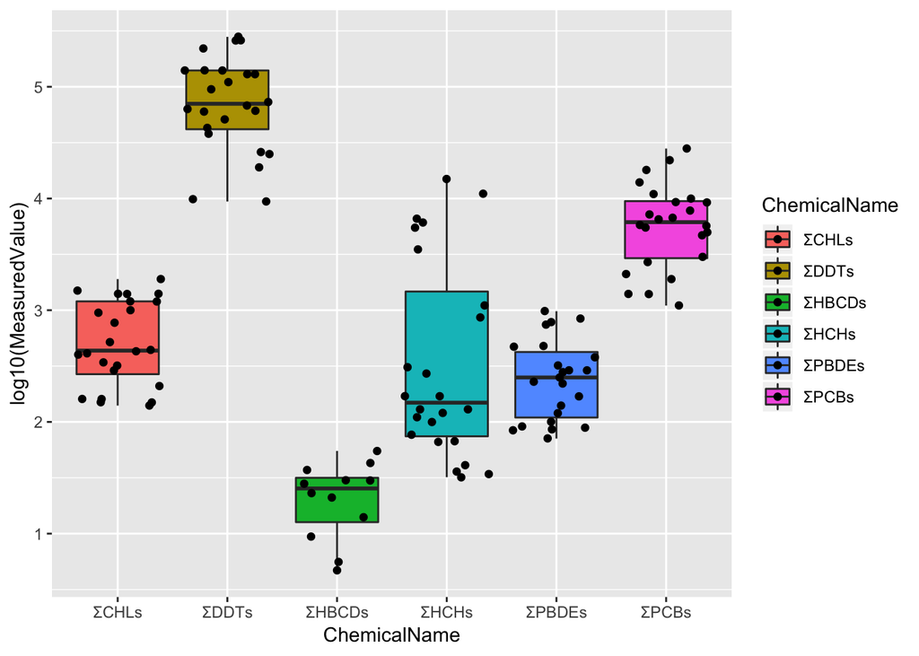

```r
ggplot(marged.total.lipid, aes(x = ChemicalName, y = log10(MeasuredValue), fill = ChemicalName)) +
  geom_boxplot() +
  geom_jitter()
```

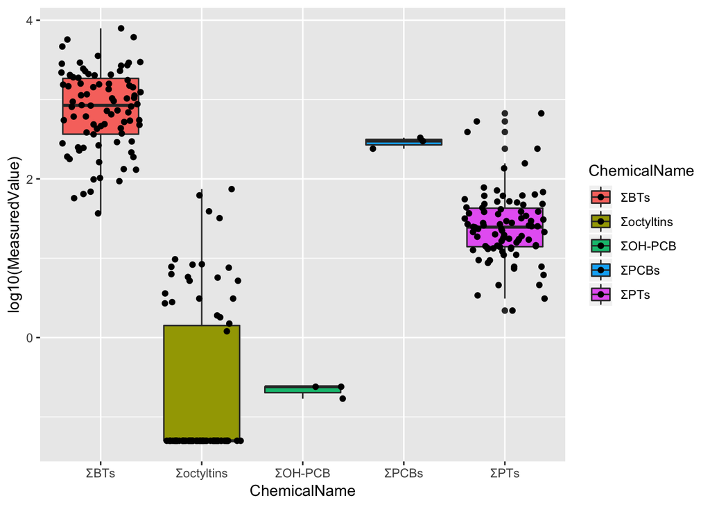

```r
ggplot(marged.total.wet, aes(x = ChemicalName, y = log10(MeasuredValue), fill = ChemicalName)) +
  geom_boxplot() +
  geom_jitter()
```

化合物名はアルファベット順で表記した。可視化には`tidyverse`パッケージ群の1つである`ggplot2`パッケージを用いた。x軸は`ChemicalName`、y軸は`MeasuredValue`とするが、y軸は`log10()`を使って対数表記にしておく。色はfillで指定する。あとは`geom_boxplot()`で箱ひげ図が、`geom_jitter()`でその上に個別検体の濃度をプロットすることができる。